# STATS531 Homework8

Xiaoyue Liu UMID:28589009 xiaoyliu@umich.edu

March 24, 2016

**1. Read in data**

- Read data from the Internet

```r
set.seed(594709947L)
require(ggplot2)
require(plyr)
require(reshape2)
require(pomp)
stopifnot(packageVersion("pomp")>="0.69-1")
dat <- read.csv("http://ionides.github.io/531w16/notes11/parus.csv")
head(dat)
```

```
##   year pop
## 1 1960 148
## 2 1961 258
## 3 1962 185
## 4 1963 170
## 5 1964 267
## 6 1965 239
```

- Let’s have a look at what the data is like

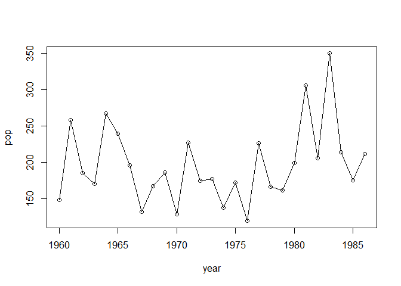

```r
plot(pop~year,data=dat,type='o')
```

**Question 8.1. Reformulating the Ricker model.**

*The Ricker equation can be reparameterized so that the scaling of $P_n$ is explicit: $P_{n+1} = r\,P_{n}\,\exp\left(-\frac{P_{n}}{k}\right).$ Modify the `pomp` object created in the notes to reflect this reparameterization. Also, Modify the measurement model so that the data ${y_n^*}$ is modeled as $Y_n |P_n \sim \mathrm{Negbin}(\phi\,P_n,\psi).$ Here, $\mathrm{Negbin}(\mu,\psi)$ is the negative binomial distribution with mean $\mu$ and probability parameter $\psi$, and therefore variance $\mu/\psi$.

- Firstly get the data into a pomp model

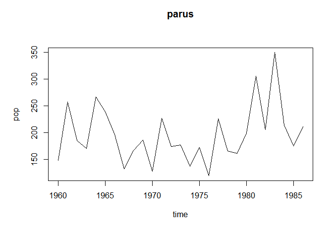

```r
parus <- pomp(dat,times="year",t0=1959)
plot(parus)
```

- Adding the determinstic using the Ricker model

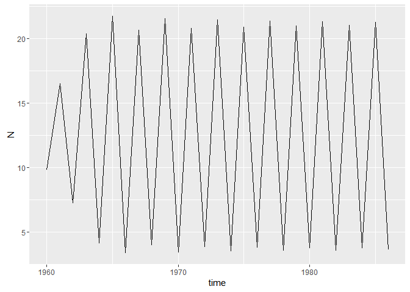

```r
skel <- Csnippet("DN = r*N*exp(-N/k);")
pomp(parus,skeleton=skel,skeleton.type='map',statenames=c("N"),paramnames=c("r","k"))->parus
traj <- trajectory(parus,params=c(N.0=1,r=12, k=5),as.data.frame=TRUE)
ggplot(data=traj,aes(x=time,y=N))+geom_line()
```

- Adding in the process model simulator

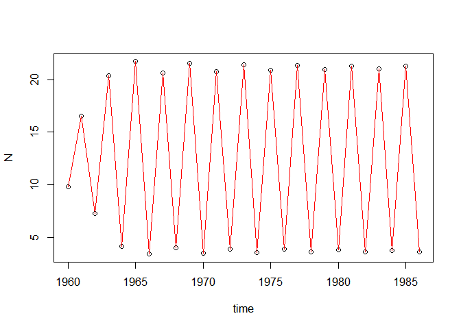

```r
stochStep <- Csnippet("N=r*N*exp(-N/k);")
pomp(parus,rprocess=discrete.time.sim(step.fun=stochStep,delta.t=1),paramnames=c("r","k"),statenames=c("N")) -> parus

sim <- simulate(parus,params=c(N.0=1,r=12,k=5),as.data.frame=TRUE,states=TRUE)
plot(N~time,data=sim,type='o')
lines(N~time,data=traj,type='l',col='red')
```

- Adding in the measurement model and parameters

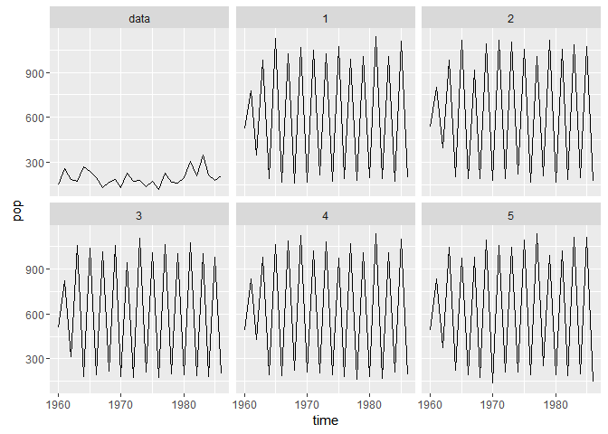

```r
rmeas <- Csnippet("pop = rnbinom(phi*N,si);")
dmeas <- Csnippet("lik = dnbinom(pop,m,mu=phi*N,si,give_log);")
pomp(parus,rmeasure=rmeas,statenames=c("N"),paramnames=c("phi","si"))->parus
coef(parus) <- c(N.0=1,r=12,phi=50,si=0.5,k=5)
sims<-simulate(parus,nsim=5,as.data.frame=TRUE,include.data=TRUE)
ggplot(data=sims,mapping=aes(x=time,y=pop))+geom_line()+
  facet_wrap(~sim)
```

**Question 8.2. Coding a new model.**

*Construct a pomp object for the* Parus major* data and the stochastic Beverton-Holt model, $P_{n+1} = \frac{a\,P_n}{1+b\,P_n}\,\varepsilon_n,$ where $a$ and $b$ are parameters and $\varepsilon_t \sim \mathrm{Lognormal}(-\tfrac{1}{2}\sigma^2,\sigma^2).$ Assume the same measurement model as we used for the Ricker model. Try simulating from a few choices of the parameters. What are the similarities and differences between simulations you obtain from the Beverton-Holt model and those from the Ricker model? Present one simulation to support your comments.

```r
parus <- pomp(dat,time="year",t0=1959)
```

- Adding the determinstic model

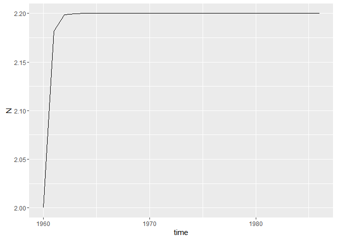

```r
skel <- Csnippet("DN = ((a*N)/(1+(b*N)));")
parus <- pomp(parus,skeleton=skel,skeleton.type='map',paramnames=c("a", "b"),statenames=c("N"))
traj <- trajectory(parus,params=c(N.0=1,a=12,b=5),as.data.frame=TRUE)
ggplot(data=traj,aes(x=time,y=N))+geom_line()
```

- Adding in the process model simulator

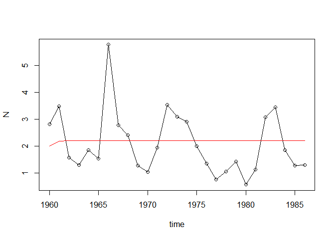

```r
stochStep <- Csnippet("
  e = rlnorm(mu,sigma);
  N = ((a*N)/(1+(b*N)))*e;
")
pomp(parus,rprocess=discrete.time.sim(step.fun=stochStep,delta.t=1),paramnames=c("a","b", "mu","sigma"),statenames=c("N","e")) -> parus
sim <- simulate(parus,params=c(N.0=1,e.0=0,a=12,b=5,sigma=0.5,mu=-0.5*(0.5)^2),as.data.frame=TRUE,states=TRUE)
plot(N~time,data=sim,type='o')
lines(N~time,data=traj,type='l',col='red')
```

- Adding in the measurement model and parameters

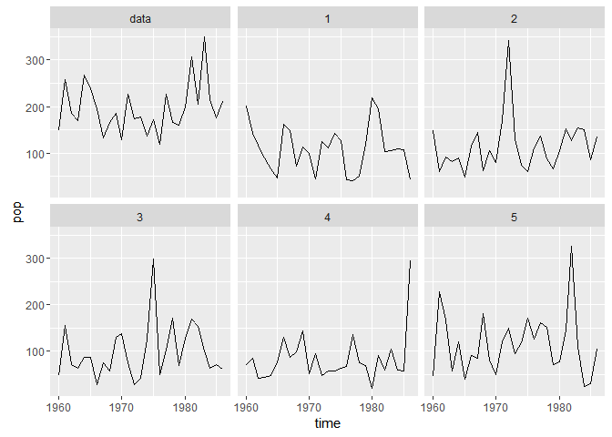

```r
rmeas <- Csnippet("pop = rpois(phi*N);")
dmeas <- Csnippet("lik = dpois(pop,phi*N,give_log);")
pomp(parus,rmeasure=rmeas,dmeasure=dmeas,statenames=c("N"),paramnames=c("phi")) -> parus
coef(parus) <- c(N.0=1,e.0=0,a=12,b=5,sigma=0.5,mu=-0.5*(0.5)^2,phi=50)
sims <- simulate(parus,nsim=5,as.data.frame=TRUE,include.data=TRUE)
ggplot(data=sims,mapping=aes(x=time,y=pop))+geom_line()+facet_wrap(~sim)
```

- The Ricker model can be seen as a limiting case of the Beverton-Holt model.The Beverton-Holt model can be generalized to include scramble competition.
- For Ricker model, the simulations are very similar in shape. For the Beverton-Holt model, the simulations change a lot in shape.

**Question 8.3.How long did this homework take?**

- It took me about 4.5 hours. 0.5 hour used to install the package. 3 hours of coding and debugging. Finally one hour to modify the parameters and write up the Rmd.